# Fifa assignment

```python
# 1) Importing required libraries
import numpy as np
import pandas as pd
import matplotlib.pyplot as plt
import seaborn as sns
```

```python
# Loading datasets and checking top 5 rows
df = pd.read_csv("fifa.csv")
df.head()
```

|  | ID | Name | Age | Photo | Nationality | Flag | Overall | Potential | Club | Club Logo | ... | Composure | Marking | StandingTackle | SlidingTackle | GKDiving | GKHandling | GKKicking | GKPositioning | GKReflexes | Release Clause |
| --- | --- | --- | --- | --- | --- | --- | --- | --- | --- | --- | --- | --- | --- | --- | --- | --- | --- | --- | --- | --- | --- |
| 0 | 158023 | L. Messi | 31 | https://cdn.sofifa.org/players/4/19/158023.png | Argentina | https://cdn.sofifa.org/flags/52.png | 94 | 94 | FC Barcelona | https://cdn.sofifa.org/teams/2/light/241.png | ... | 96.0 | 33.0 | 28.0 | 26.0 | 6.0 | 11.0 | 15.0 | 14.0 | 8.0 | €226.5M |
| 1 | 20801 | Cristiano Ronaldo | 33 | https://cdn.sofifa.org/players/4/19/20801.png | Portugal | https://cdn.sofifa.org/flags/38.png | 94 | 94 | Juventus | https://cdn.sofifa.org/teams/2/light/45.png | ... | 95.0 | 28.0 | 31.0 | 23.0 | 7.0 | 11.0 | 15.0 | 14.0 | 11.0 | €127.1M |
| 2 | 190871 | Neymar Jr | 26 | https://cdn.sofifa.org/players/4/19/190871.png | Brazil | https://cdn.sofifa.org/flags/54.png | 92 | 93 | Paris Saint-Germain | https://cdn.sofifa.org/teams/2/light/73.png | ... | 94.0 | 27.0 | 24.0 | 33.0 | 9.0 | 9.0 | 15.0 | 15.0 | 11.0 | €228.1M |
| 3 | 193080 | De Gea | 27 | https://cdn.sofifa.org/players/4/19/193080.png | Spain | https://cdn.sofifa.org/flags/45.png | 91 | 93 | Manchester United | https://cdn.sofifa.org/teams/2/light/11.png | ... | 68.0 | 15.0 | 21.0 | 13.0 | 90.0 | 85.0 | 87.0 | 88.0 | 94.0 | €138.6M |
| 4 | 192985 | K. De Bruyne | 27 | https://cdn.sofifa.org/players/4/19/192985.png | Belgium | https://cdn.sofifa.org/flags/7.png | 91 | 92 | Manchester City | https://cdn.sofifa.org/teams/2/light/10.png | ... | 88.0 | 68.0 | 58.0 | 51.0 | 15.0 | 13.0 | 5.0 | 10.0 | 13.0 | €196.4M |

5 rows × 60 columns

```
                                                    --------
```

```python
# 2) Shape of the dataset
df.shape
```

```
(18207, 60)
```

There are 18207 players information with 60 features/parameters

```python
# 5 point summary
df.describe()
```

|  | ID | Age | Overall | Potential | International Reputation | Weak Foot | Skill Moves | Jersey Number | Crossing | Finishing | ... | Penalties | Composure | Marking | StandingTackle | SlidingTackle | GKDiving | GKHandling | GKKicking | GKPositioning | GKReflexes |
| --- | --- | --- | --- | --- | --- | --- | --- | --- | --- | --- | --- | --- | --- | --- | --- | --- | --- | --- | --- | --- | --- |
| count | 18207.000000 | 18207.000000 | 18207.000000 | 18207.000000 | 18159.000000 | 18159.000000 | 18159.000000 | 18147.000000 | 18159.000000 | 18159.000000 | ... | 18159.000000 | 18159.000000 | 18159.000000 | 18159.000000 | 18159.000000 | 18159.000000 | 18159.000000 | 18159.000000 | 18159.000000 | 18159.000000 |
| mean | 214298.338606 | 25.122206 | 66.238699 | 71.307299 | 1.113222 | 2.947299 | 2.361308 | 19.546096 | 49.734181 | 45.550911 | ... | 48.548598 | 58.648274 | 47.281623 | 47.697836 | 45.661435 | 16.616223 | 16.391596 | 16.232061 | 16.388898 | 16.710887 |
| std | 29965.244204 | 4.669943 | 6.908930 | 6.136496 | 0.394031 | 0.660456 | 0.756164 | 15.947765 | 18.364524 | 19.525820 | ... | 15.704053 | 11.436133 | 19.904397 | 21.664004 | 21.289135 | 17.695349 | 16.906900 | 16.502864 | 17.034669 | 17.955119 |
| min | 16.000000 | 16.000000 | 46.000000 | 48.000000 | 1.000000 | 1.000000 | 1.000000 | 1.000000 | 5.000000 | 2.000000 | ... | 5.000000 | 3.000000 | 3.000000 | 2.000000 | 3.000000 | 1.000000 | 1.000000 | 1.000000 | 1.000000 | 1.000000 |
| 25% | 200315.500000 | 21.000000 | 62.000000 | 67.000000 | 1.000000 | 3.000000 | 2.000000 | 8.000000 | 38.000000 | 30.000000 | ... | 39.000000 | 51.000000 | 30.000000 | 27.000000 | 24.000000 | 8.000000 | 8.000000 | 8.000000 | 8.000000 | 8.000000 |
| 50% | 221759.000000 | 25.000000 | 66.000000 | 71.000000 | 1.000000 | 3.000000 | 2.000000 | 17.000000 | 54.000000 | 49.000000 | ... | 49.000000 | 60.000000 | 53.000000 | 55.000000 | 52.000000 | 11.000000 | 11.000000 | 11.000000 | 11.000000 | 11.000000 |
| 75% | 236529.500000 | 28.000000 | 71.000000 | 75.000000 | 1.000000 | 3.000000 | 3.000000 | 26.000000 | 64.000000 | 62.000000 | ... | 60.000000 | 67.000000 | 64.000000 | 66.000000 | 64.000000 | 14.000000 | 14.000000 | 14.000000 | 14.000000 | 14.000000 |
| max | 246620.000000 | 45.000000 | 94.000000 | 95.000000 | 5.000000 | 5.000000 | 5.000000 | 99.000000 | 93.000000 | 95.000000 | ... | 92.000000 | 96.000000 | 94.000000 | 93.000000 | 91.000000 | 90.000000 | 92.000000 | 91.000000 | 90.000000 | 94.000000 |

8 rows × 42 columns

```python
# Loading fifa_ variable_information dataset and loading top 5 rows
df1 = pd.read_csv("fifa_ variable_information.csv")
print("Shape of data: ", df1.shape)
df1.head(70)
```

```
Shape of data:  (59, 2)
```

|  | ID | unique id for every player |
| --- | --- | --- |
| 0 | Name | name |
| 1 | Age | age |
| 2 | Photo | url to the player's photo |
| 3 | Nationality | nationality |
| 4 | Flag | url to players's country flag |
| 5 | Overall | overall rating |
| 6 | Potential | potential rating |
| 7 | Club | current club |
| 8 | Club Logo | url to club logo |
| 9 | Value | current market value |
| 10 | Wage | current wage |
| 11 | Preferred Foot | left/right |
| 12 | International Reputation | rating on scale of 5 |
| 13 | Weak Foot | rating on scale of 5 |
| 14 | Skill Moves | rating on scale of 5 |
| 15 | Work Rate | attack work rate/defence work rate |
| 16 | Body Type | body type of player |
| 17 | Position | position on the pitch |
| 18 | Jersey Number | jersey number |
| 19 | Joined | joined date |
| 20 | Loaned From | club name if applicable |
| 21 | Contract Valid Until | contract end date |
| 22 | Height | height of the player |
| 23 | Weight | weight of the player |
| 24 | Crossing | rating on scale of 100 |
| 25 | Finishing | rating on scale of 100 |
| 26 | HeadingAccuracy | rating on scale of 100 |
| 27 | ShortPassing | rating on scale of 100 |
| 28 | Volleys | rating on scale of 100 |
| 29 | Dribbling | rating on scale of 100 |
| 30 | Curve | rating on scale of 100 |
| 31 | FKAccuracy | rating on scale of 100 |
| 32 | LongPassing | rating on scale of 100 |
| 33 | BallControl | rating on scale of 100 |
| 34 | Acceleration | rating on scale of 100 |
| 35 | SprintSpeed | rating on scale of 100 |
| 36 | Agility | rating on scale of 100 |
| 37 | Reactions | rating on scale of 100\ |
| 38 | Balance | rating on scale of 100 |
| 39 | ShotPower | rating on scale of 100 |
| 40 | Jumping | rating on scale of 100 |
| 41 | Stamina | rating on scale of 100 |
| 42 | Strength | rating on scale of 100 |
| 43 | LongShots | rating on scale of 100 |
| 44 | Aggression | rating on scale of 100 |
| 45 | Interceptions | rating on scale of 100 |
| 46 | Positioning | rating on scale of 100 |
| 47 | Vision | rating on scale of 100 |
| 48 | Penalties | rating on scale of 100 |
| 49 | Composure | rating on scale of 100 |
| 50 | Marking | rating on scale of 100 |
| 51 | StandingTackle | rating on scale of 100 |
| 52 | SlidingTackle | rating on scale of 100 |
| 53 | GKDiving | rating on scale of 100 |
| 54 | GKHandling | rating on scale of 100 |
| 55 | GKKicking | rating on scale of 100 |
| 56 | GKPositioning | rating on scale of 100 |
| 57 | GKReflexes | rating on scale of 100 |
| 58 | Release Clause | release clause value |

This is a descriptive table to the previous tables

```python
# 2) Checking the information on the df dataset
df.info()
```

```
<class 'pandas.core.frame.DataFrame'>
RangeIndex: 18207 entries, 0 to 18206
Data columns (total 60 columns):
 #   Column                    Non-Null Count  Dtype
---  ------                    --------------  -----
 0   ID                        18207 non-null  int64
 1   Name                      18207 non-null  object
 2   Age                       18207 non-null  int64
 3   Photo                     18207 non-null  object
 4   Nationality               18207 non-null  object
 5   Flag                      18207 non-null  object
 6   Overall                   18207 non-null  int64
 7   Potential                 18207 non-null  int64
 8   Club                      17966 non-null  object
 9   Club Logo                 18207 non-null  object
```

[output cut: 52 more lines]

```
                                                    ----------
```

```python
# 3) trying to understand columns to see if they are redundant
df['International Reputation'].value_counts()
```

```
1.0    16532
2.0     1261
3.0      309
4.0       51
5.0        6
Name: International Reputation, dtype: int64
```

It is important as it might help us scout the highly reputed players closely.

```python
# 3) Dropping redundant columns
df = df.drop(['Photo','Flag','Club Logo','Jersey Number'], axis=1)
df.shape
```

```
(18207, 56)
```

Dropped 4 redundant columns

```python
# New DataFrame
df
```

|  | ID | Name | Age | Nationality | Overall | Potential | Club | Value | Wage | Preferred Foot | ... | Composure | Marking | StandingTackle | SlidingTackle | GKDiving | GKHandling | GKKicking | GKPositioning | GKReflexes | Release Clause |
| --- | --- | --- | --- | --- | --- | --- | --- | --- | --- | --- | --- | --- | --- | --- | --- | --- | --- | --- | --- | --- | --- |
| 0 | 158023 | L. Messi | 31 | Argentina | 94 | 94 | FC Barcelona | €110.5M | €565K | Left | ... | 96.0 | 33.0 | 28.0 | 26.0 | 6.0 | 11.0 | 15.0 | 14.0 | 8.0 | €226.5M |
| 1 | 20801 | Cristiano Ronaldo | 33 | Portugal | 94 | 94 | Juventus | €77M | €405K | Right | ... | 95.0 | 28.0 | 31.0 | 23.0 | 7.0 | 11.0 | 15.0 | 14.0 | 11.0 | €127.1M |
| 2 | 190871 | Neymar Jr | 26 | Brazil | 92 | 93 | Paris Saint-Germain | €118.5M | €290K | Right | ... | 94.0 | 27.0 | 24.0 | 33.0 | 9.0 | 9.0 | 15.0 | 15.0 | 11.0 | €228.1M |
| 3 | 193080 | De Gea | 27 | Spain | 91 | 93 | Manchester United | €72M | €260K | Right | ... | 68.0 | 15.0 | 21.0 | 13.0 | 90.0 | 85.0 | 87.0 | 88.0 | 94.0 | €138.6M |
| 4 | 192985 | K. De Bruyne | 27 | Belgium | 91 | 92 | Manchester City | €102M | €355K | Right | ... | 88.0 | 68.0 | 58.0 | 51.0 | 15.0 | 13.0 | 5.0 | 10.0 | 13.0 | €196.4M |
| ... | ... | ... | ... | ... | ... | ... | ... | ... | ... | ... | ... | ... | ... | ... | ... | ... | ... | ... | ... | ... | ... |
| 18202 | 238813 | J. Lundstram | 19 | England | 47 | 65 | Crewe Alexandra | €60K | €1K | Right | ... | 45.0 | 40.0 | 48.0 | 47.0 | 10.0 | 13.0 | 7.0 | 8.0 | 9.0 | €143K |
| 18203 | 243165 | N. Christoffersson | 19 | Sweden | 47 | 63 | Trelleborgs FF | €60K | €1K | Right | ... | 42.0 | 22.0 | 15.0 | 19.0 | 10.0 | 9.0 | 9.0 | 5.0 | 12.0 | €113K |
| 18204 | 241638 | B. Worman | 16 | England | 47 | 67 | Cambridge United | €60K | €1K | Right | ... | 41.0 | 32.0 | 13.0 | 11.0 | 6.0 | 5.0 | 10.0 | 6.0 | 13.0 | €165K |
| 18205 | 246268 | D. Walker-Rice | 17 | England | 47 | 66 | Tranmere Rovers | €60K | €1K | Right | ... | 46.0 | 20.0 | 25.0 | 27.0 | 14.0 | 6.0 | 14.0 | 8.0 | 9.0 | €143K |
| 18206 | 246269 | G. Nugent | 16 | England | 46 | 66 | Tranmere Rovers | €60K | €1K | Right | ... | 43.0 | 40.0 | 43.0 | 50.0 | 10.0 | 15.0 | 9.0 | 12.0 | 9.0 | €165K |

18207 rows × 56 columns

```
                                                        ----------
```

```python
# 4) Converting Object to float datatype
```

```python
# Removing currency symbol from Value
df['Value']=df['Value'].str[1:]
df['Value']
```

```
0        110.5M
1           77M
2        118.5M
3           72M
4          102M
          ...
18202       60K
18203       60K
18204       60K
18205       60K
18206       60K
Name: Value, Length: 18207, dtype: object
```

```python
# Removing currency symbol from Wage
df['Wage']=df['Wage'].str[1:]
df['Wage']
```

```
0        565K
1        405K
2        290K
3        260K
4        355K
         ...
18202      1K
18203      1K
18204      1K
18205      1K
18206      1K
Name: Wage, Length: 18207, dtype: object
```

```python
# Removing currency symbol from Release Clause
df['Release Clause']=df['Release Clause'].str[1:]
df['Release Clause']
```

```
0        226.5M
1        127.1M
2        228.1M
3        138.6M
4        196.4M
          ...
18202      143K
18203      113K
18204      165K
18205      143K
18206      165K
Name: Release Clause, Length: 18207, dtype: object
```

```python
# 4) Converting M to million K to thousand.

def value_to_float(x):
    if type(x) == float or type(x) == int:
        return x
    if 'K' in x:
        if len(x) > 1:
            return float(x.replace('K', '')) * 1000
        return 1000.0
    if 'M' in x:
        if len(x) > 1:
            return float(x.replace('M', '')) * 1000000
        return 1000000.0
    if 'B' in x:
        return float(x.replace('B', '')) * 1000000000
    return 0.0

df['Wage'] = df['Wage'].apply(value_to_float)
```

```python
# Displaying the converted form of Wage column
df['Wage']
```

```
0        565000.0
1        405000.0
2        290000.0
3        260000.0
4        355000.0
           ...
18202      1000.0
18203      1000.0
18204      1000.0
18205      1000.0
18206      1000.0
Name: Wage, Length: 18207, dtype: float64
```

```python
# Displaying the converted form of Value column
df['Value'] = df['Value'].apply(value_to_float)
df['Value']
```

```
0        110500000.0
1         77000000.0
2        118500000.0
3         72000000.0
4        102000000.0
            ...
18202        60000.0
18203        60000.0
18204        60000.0
18205        60000.0
18206        60000.0
Name: Value, Length: 18207, dtype: float64
```

```python
# Displaying the converted form of Release Clause column
df['Release Clause'] = df['Release Clause'].apply(value_to_float)
df['Release Clause']
```

```
0        226500000.0
1        127100000.0
2        228100000.0
3        138600000.0
4        196400000.0
            ...
18202       143000.0
18203       113000.0
18204       165000.0
18205       143000.0
18206       165000.0
Name: Release Clause, Length: 18207, dtype: float64
```

```python
# Now changing the datatype
df['Value'] = pd.to_numeric(df['Value'],downcast='float')
df.dtypes
```

```
ID                            int64
Name                         object
Age                           int64
Nationality                  object
Overall                       int64
Potential                     int64
Club                         object
Value                       float32
Wage                        float64
Preferred Foot               object
International Reputation    float64
Weak Foot                   float64
Skill Moves                 float64
Work Rate                    object
Body Type                    object
Position                     object
Joined                       object
Loaned From                  object
Contract Valid Until         object
Height                       object
Weight                       object
Crossing                    float64
Finishing                   float64
HeadingAccuracy             float64
ShortPassing                float64
Volleys                     float64
Dribbling                   float64
Curve                       float64
FKAccuracy                  float64
LongPassing                 float64
BallControl                 float64
Acceleration                float64
SprintSpeed                 float64
Agility                     float64
Reactions                   float64
Balance                     float64
ShotPower                   float64
Jumping                     float64
Stamina                     float64
Strength                    float64
LongShots                   float64
Aggression                  float64
Interceptions               float64
Positioning                 float64
Vision                      float64
Penalties                   float64
Composure                   float64
Marking                     float64
StandingTackle              float64
SlidingTackle               float64
GKDiving                    float64
GKHandling                  float64
GKKicking                   float64
GKPositioning               float64
GKReflexes                  float64
Release Clause              float64
dtype: object
```

```python
df['Release Clause'] = pd.to_numeric(df['Release Clause'],downcast='float')
df.dtypes
```

```
ID                            int64
Name                         object
Age                           int64
Nationality                  object
Overall                       int64
Potential                     int64
Club                         object
Value                       float32
Wage                        float64
Preferred Foot               object
International Reputation    float64
Weak Foot                   float64
Skill Moves                 float64
Work Rate                    object
Body Type                    object
Position                     object
Joined                       object
Loaned From                  object
Contract Valid Until         object
Height                       object
Weight                       object
Crossing                    float64
Finishing                   float64
HeadingAccuracy             float64
ShortPassing                float64
Volleys                     float64
Dribbling                   float64
Curve                       float64
FKAccuracy                  float64
LongPassing                 float64
BallControl                 float64
Acceleration                float64
SprintSpeed                 float64
Agility                     float64
Reactions                   float64
Balance                     float64
ShotPower                   float64
Jumping                     float64
Stamina                     float64
Strength                    float64
LongShots                   float64
Aggression                  float64
Interceptions               float64
Positioning                 float64
Vision                      float64
Penalties                   float64
Composure                   float64
Marking                     float64
StandingTackle              float64
SlidingTackle               float64
GKDiving                    float64
GKHandling                  float64
GKKicking                   float64
GKPositioning               float64
GKReflexes                  float64
Release Clause              float32
dtype: object
```

```python
# The new Dataframe
df
```

|  | ID | Name | Age | Nationality | Overall | Potential | Club | Value | Wage | Preferred Foot | ... | Composure | Marking | StandingTackle | SlidingTackle | GKDiving | GKHandling | GKKicking | GKPositioning | GKReflexes | Release Clause |
| --- | --- | --- | --- | --- | --- | --- | --- | --- | --- | --- | --- | --- | --- | --- | --- | --- | --- | --- | --- | --- | --- |
| 0 | 158023 | L. Messi | 31 | Argentina | 94 | 94 | FC Barcelona | 110500000.0 | 565000.0 | Left | ... | 96.0 | 33.0 | 28.0 | 26.0 | 6.0 | 11.0 | 15.0 | 14.0 | 8.0 | 226500000.0 |
| 1 | 20801 | Cristiano Ronaldo | 33 | Portugal | 94 | 94 | Juventus | 77000000.0 | 405000.0 | Right | ... | 95.0 | 28.0 | 31.0 | 23.0 | 7.0 | 11.0 | 15.0 | 14.0 | 11.0 | 127100000.0 |
| 2 | 190871 | Neymar Jr | 26 | Brazil | 92 | 93 | Paris Saint-Germain | 118500000.0 | 290000.0 | Right | ... | 94.0 | 27.0 | 24.0 | 33.0 | 9.0 | 9.0 | 15.0 | 15.0 | 11.0 | 228100000.0 |
| 3 | 193080 | De Gea | 27 | Spain | 91 | 93 | Manchester United | 72000000.0 | 260000.0 | Right | ... | 68.0 | 15.0 | 21.0 | 13.0 | 90.0 | 85.0 | 87.0 | 88.0 | 94.0 | 138600000.0 |
| 4 | 192985 | K. De Bruyne | 27 | Belgium | 91 | 92 | Manchester City | 102000000.0 | 355000.0 | Right | ... | 88.0 | 68.0 | 58.0 | 51.0 | 15.0 | 13.0 | 5.0 | 10.0 | 13.0 | 196400000.0 |
| ... | ... | ... | ... | ... | ... | ... | ... | ... | ... | ... | ... | ... | ... | ... | ... | ... | ... | ... | ... | ... | ... |
| 18202 | 238813 | J. Lundstram | 19 | England | 47 | 65 | Crewe Alexandra | 60000.0 | 1000.0 | Right | ... | 45.0 | 40.0 | 48.0 | 47.0 | 10.0 | 13.0 | 7.0 | 8.0 | 9.0 | 143000.0 |
| 18203 | 243165 | N. Christoffersson | 19 | Sweden | 47 | 63 | Trelleborgs FF | 60000.0 | 1000.0 | Right | ... | 42.0 | 22.0 | 15.0 | 19.0 | 10.0 | 9.0 | 9.0 | 5.0 | 12.0 | 113000.0 |
| 18204 | 241638 | B. Worman | 16 | England | 47 | 67 | Cambridge United | 60000.0 | 1000.0 | Right | ... | 41.0 | 32.0 | 13.0 | 11.0 | 6.0 | 5.0 | 10.0 | 6.0 | 13.0 | 165000.0 |
| 18205 | 246268 | D. Walker-Rice | 17 | England | 47 | 66 | Tranmere Rovers | 60000.0 | 1000.0 | Right | ... | 46.0 | 20.0 | 25.0 | 27.0 | 14.0 | 6.0 | 14.0 | 8.0 | 9.0 | 143000.0 |
| 18206 | 246269 | G. Nugent | 16 | England | 46 | 66 | Tranmere Rovers | 60000.0 | 1000.0 | Right | ... | 43.0 | 40.0 | 43.0 | 50.0 | 10.0 | 15.0 | 9.0 | 12.0 | 9.0 | 165000.0 |

18207 rows × 56 columns

```
                                                        ----------
```

```python
# 5) Convert "Joined" column to year by parsing the column and then converting into int32
df['Joined'] = df['Joined'].str[-4:]
```

```python
df['Joined'] = df['Joined'].astype('Int32')
```

```python
df['Joined']
```

```
0        2004
1        2018
2        2017
3        2011
4        2015
         ...
18202    2017
18203    2018
18204    2017
18205    2018
18206    2018
Name: Joined, Length: 18207, dtype: Int32
```

```python
df.info()
```

```
<class 'pandas.core.frame.DataFrame'>
RangeIndex: 18207 entries, 0 to 18206
Data columns (total 56 columns):
 #   Column                    Non-Null Count  Dtype
---  ------                    --------------  -----
 0   ID                        18207 non-null  int64
 1   Name                      18207 non-null  object
 2   Age                       18207 non-null  int64
 3   Nationality               18207 non-null  object
 4   Overall                   18207 non-null  int64
 5   Potential                 18207 non-null  int64
 6   Club                      17966 non-null  object
 7   Value                     18207 non-null  float32
 8   Wage                      18207 non-null  float64
 9   Preferred Foot            18159 non-null  object
```

[output cut: 48 more lines]

```
                                                        ----------
```

```python
# 6) Converting Contract Valid until column to datetime type

df['Contract Valid Until'] = df['Contract Valid Until'].astype('datetime64')
```

```python
df['Contract Valid Until']
```

```
0       2021-01-01
1       2022-01-01
2       2022-01-01
3       2020-01-01
4       2023-01-01
           ...
18202   2019-01-01
18203   2020-01-01
18204   2021-01-01
18205   2019-01-01
18206   2019-01-01
Name: Contract Valid Until, Length: 18207, dtype: datetime64[ns]
```

```
                                                        ----------
```

```python
# 7) Changing the ' in height with . and converting it to float datatype
df['Height'] = df['Height'].str.replace("'",".")
```

```python
df['Height']
```

```
0         5.7
1         6.2
2         5.9
3         6.4
4        5.11
         ...
18202     5.9
18203     6.3
18204     5.8
18205    5.10
18206    5.10
Name: Height, Length: 18207, dtype: object
```

```python
# Float type conversion
df['Height'] = df['Height'].astype(float)
df.dtypes
```

[output not shown]

```
                                                            ----------
```

```python
# 8) Removing lbs from the suffix
df['Weight'] = df['Weight'].str[:-3]
df['Weight']
```

```
0        159
1        183
2        150
3        168
4        154
        ...
18202    134
18203    170
18204    148
18205    154
18206    176
Name: Weight, Length: 18207, dtype: object
```

```python
# Converting column weight to float
df['Weight'] = df['Weight'].astype(float)
df.dtypes
```

[output not shown]

```
                                                        ----------
```

```python
# 9) Percentage missing values and imputation
percentage_missing_values = df.isnull().sum()*100 / len(df)
percentage_missing_values
```

```
ID                           0.000000
Name                         0.000000
Age                          0.000000
Nationality                  0.000000
Overall                      0.000000
Potential                    0.000000
Club                         1.323667
Value                        0.000000
Wage                         0.000000
Preferred Foot               0.263635
International Reputation     0.263635
Weak Foot                    0.263635
Skill Moves                  0.263635
Work Rate                    0.263635
Body Type                    0.263635
Position                     0.329544
Joined                       8.529686
Loaned From                 93.057615
Contract Valid Until         1.587302
Height                       0.263635
Weight                       0.263635
Crossing                     0.263635
Finishing                    0.263635
HeadingAccuracy              0.263635
ShortPassing                 0.263635
Volleys                      0.263635
Dribbling                    0.263635
Curve                        0.263635
FKAccuracy                   0.263635
LongPassing                  0.263635
BallControl                  0.263635
Acceleration                 0.263635
SprintSpeed                  0.263635
Agility                      0.263635
Reactions                    0.263635
Balance                      0.263635
ShotPower                    0.263635
Jumping                      0.263635
Stamina                      0.263635
Strength                     0.263635
LongShots                    0.263635
Aggression                   0.263635
Interceptions                0.263635
Positioning                  0.263635
Vision                       0.263635
Penalties                    0.263635
Composure                    0.263635
Marking                      0.263635
StandingTackle               0.263635
SlidingTackle                0.263635
GKDiving                     0.263635
GKHandling                   0.263635
GKKicking                    0.263635
GKPositioning                0.263635
GKReflexes                   0.263635
Release Clause               8.590103
dtype: float64
```

1) Loaned From (has 93% missing values) is the club from where the player moves on a temporary basis hence it is a object datatype, it does not help us in any numeric analysis hence we can delete the column.

2) Release clause has 8.59% values missing we can impute it with median value of the Release Clause. Rest all the columns have very less missing values and can be ignored

```python
# Dropping the "Loaned from" Column

df = df.drop(['Loaned From'], axis=1)
df
```

|  | ID | Name | Age | Nationality | Overall | Potential | Club | Value | Wage | Preferred Foot | ... | Composure | Marking | StandingTackle | SlidingTackle | GKDiving | GKHandling | GKKicking | GKPositioning | GKReflexes | Release Clause |
| --- | --- | --- | --- | --- | --- | --- | --- | --- | --- | --- | --- | --- | --- | --- | --- | --- | --- | --- | --- | --- | --- |
| 0 | 158023 | L. Messi | 31 | Argentina | 94 | 94 | FC Barcelona | 110500000.0 | 565000.0 | Left | ... | 96.0 | 33.0 | 28.0 | 26.0 | 6.0 | 11.0 | 15.0 | 14.0 | 8.0 | 226500000.0 |
| 1 | 20801 | Cristiano Ronaldo | 33 | Portugal | 94 | 94 | Juventus | 77000000.0 | 405000.0 | Right | ... | 95.0 | 28.0 | 31.0 | 23.0 | 7.0 | 11.0 | 15.0 | 14.0 | 11.0 | 127100000.0 |
| 2 | 190871 | Neymar Jr | 26 | Brazil | 92 | 93 | Paris Saint-Germain | 118500000.0 | 290000.0 | Right | ... | 94.0 | 27.0 | 24.0 | 33.0 | 9.0 | 9.0 | 15.0 | 15.0 | 11.0 | 228100000.0 |
| 3 | 193080 | De Gea | 27 | Spain | 91 | 93 | Manchester United | 72000000.0 | 260000.0 | Right | ... | 68.0 | 15.0 | 21.0 | 13.0 | 90.0 | 85.0 | 87.0 | 88.0 | 94.0 | 138600000.0 |
| 4 | 192985 | K. De Bruyne | 27 | Belgium | 91 | 92 | Manchester City | 102000000.0 | 355000.0 | Right | ... | 88.0 | 68.0 | 58.0 | 51.0 | 15.0 | 13.0 | 5.0 | 10.0 | 13.0 | 196400000.0 |
| ... | ... | ... | ... | ... | ... | ... | ... | ... | ... | ... | ... | ... | ... | ... | ... | ... | ... | ... | ... | ... | ... |
| 18202 | 238813 | J. Lundstram | 19 | England | 47 | 65 | Crewe Alexandra | 60000.0 | 1000.0 | Right | ... | 45.0 | 40.0 | 48.0 | 47.0 | 10.0 | 13.0 | 7.0 | 8.0 | 9.0 | 143000.0 |
| 18203 | 243165 | N. Christoffersson | 19 | Sweden | 47 | 63 | Trelleborgs FF | 60000.0 | 1000.0 | Right | ... | 42.0 | 22.0 | 15.0 | 19.0 | 10.0 | 9.0 | 9.0 | 5.0 | 12.0 | 113000.0 |
| 18204 | 241638 | B. Worman | 16 | England | 47 | 67 | Cambridge United | 60000.0 | 1000.0 | Right | ... | 41.0 | 32.0 | 13.0 | 11.0 | 6.0 | 5.0 | 10.0 | 6.0 | 13.0 | 165000.0 |
| 18205 | 246268 | D. Walker-Rice | 17 | England | 47 | 66 | Tranmere Rovers | 60000.0 | 1000.0 | Right | ... | 46.0 | 20.0 | 25.0 | 27.0 | 14.0 | 6.0 | 14.0 | 8.0 | 9.0 | 143000.0 |
| 18206 | 246269 | G. Nugent | 16 | England | 46 | 66 | Tranmere Rovers | 60000.0 | 1000.0 | Right | ... | 43.0 | 40.0 | 43.0 | 50.0 | 10.0 | 15.0 | 9.0 | 12.0 | 9.0 | 165000.0 |

18207 rows × 55 columns

```python
# Imputing median value for "Release clause" column
df['Release Clause'] = df['Release Clause'].fillna(df['Release Clause'].median())
df.isnull().sum()/len(df)*100
```

```
ID                          0.000000
Name                        0.000000
Age                         0.000000
Nationality                 0.000000
Overall                     0.000000
Potential                   0.000000
Club                        1.323667
Value                       0.000000
Wage                        0.000000
Preferred Foot              0.263635
International Reputation    0.263635
Weak Foot                   0.263635
Skill Moves                 0.263635
Work Rate                   0.263635
Body Type                   0.263635
Position                    0.329544
Joined                      8.529686
Contract Valid Until        1.587302
Height                      0.263635
Weight                      0.263635
Crossing                    0.263635
Finishing                   0.263635
HeadingAccuracy             0.263635
ShortPassing                0.263635
Volleys                     0.263635
Dribbling                   0.263635
Curve                       0.263635
FKAccuracy                  0.263635
LongPassing                 0.263635
BallControl                 0.263635
Acceleration                0.263635
SprintSpeed                 0.263635
Agility                     0.263635
Reactions                   0.263635
Balance                     0.263635
ShotPower                   0.263635
Jumping                     0.263635
Stamina                     0.263635
Strength                    0.263635
LongShots                   0.263635
Aggression                  0.263635
Interceptions               0.263635
Positioning                 0.263635
Vision                      0.263635
Penalties                   0.263635
Composure                   0.263635
Marking                     0.263635
StandingTackle              0.263635
SlidingTackle               0.263635
GKDiving                    0.263635
GKHandling                  0.263635
GKKicking                   0.263635
GKPositioning               0.263635
GKReflexes                  0.263635
Release Clause              0.000000
dtype: float64
```

Performed median imputation on Release Clause column

```
                                                        -----------
```

# Exploratory Data Analysis

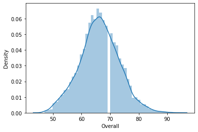

```python
# 10) Distribution of overall ratings

sns.distplot(a=df['Overall'])
```

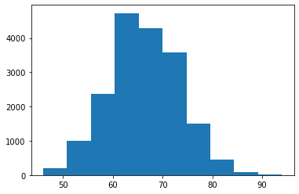

```python
# Distribution chart
plt.hist(df['Overall'])
plt.plot()
plt.show()
```

1) The overalls are normally distributed, hence they can be used for further statistical tests.

2) Majority of the datapoints fall in the mean plus or minus 2 sigma range

3) Very few players have their overall are in the above 90+ and lower than 50

4) To understand the distribution of overalls in bins of 10 we can have a look at the distribution above

```
                                                        ----------
```

```python
# 11) TOP 20 Players based on overall ratings
df.nlargest(20,'Overall')['Name']
```

```
0              L. Messi
1     Cristiano Ronaldo
2             Neymar Jr
3                De Gea
4          K. De Bruyne
5             E. Hazard
6             L. Modrić
7             L. Suárez
8          Sergio Ramos
9              J. Oblak
10       R. Lewandowski
11             T. Kroos
12             D. Godín
13          David Silva
14             N. Kanté
15            P. Dybala
16              H. Kane
17         A. Griezmann
18        M. ter Stegen
19          T. Courtois
Name: Name, dtype: object
```

```
                                                            ----------
```

```python
# 12) A dataframe of full information of top 20 Overall rated players
df_top_20 = df.nlargest(20,'Overall')
df_top_20
```

|  | ID | Name | Age | Nationality | Overall | Potential | Club | Value | Wage | Preferred Foot | ... | Composure | Marking | StandingTackle | SlidingTackle | GKDiving | GKHandling | GKKicking | GKPositioning | GKReflexes | Release Clause |
| --- | --- | --- | --- | --- | --- | --- | --- | --- | --- | --- | --- | --- | --- | --- | --- | --- | --- | --- | --- | --- | --- |
| 0 | 158023 | L. Messi | 31 | Argentina | 94 | 94 | FC Barcelona | 110500000.0 | 565000.0 | Left | ... | 96.0 | 33.0 | 28.0 | 26.0 | 6.0 | 11.0 | 15.0 | 14.0 | 8.0 | 226500000.0 |
| 1 | 20801 | Cristiano Ronaldo | 33 | Portugal | 94 | 94 | Juventus | 77000000.0 | 405000.0 | Right | ... | 95.0 | 28.0 | 31.0 | 23.0 | 7.0 | 11.0 | 15.0 | 14.0 | 11.0 | 127100000.0 |
| 2 | 190871 | Neymar Jr | 26 | Brazil | 92 | 93 | Paris Saint-Germain | 118500000.0 | 290000.0 | Right | ... | 94.0 | 27.0 | 24.0 | 33.0 | 9.0 | 9.0 | 15.0 | 15.0 | 11.0 | 228100000.0 |
| 3 | 193080 | De Gea | 27 | Spain | 91 | 93 | Manchester United | 72000000.0 | 260000.0 | Right | ... | 68.0 | 15.0 | 21.0 | 13.0 | 90.0 | 85.0 | 87.0 | 88.0 | 94.0 | 138600000.0 |
| 4 | 192985 | K. De Bruyne | 27 | Belgium | 91 | 92 | Manchester City | 102000000.0 | 355000.0 | Right | ... | 88.0 | 68.0 | 58.0 | 51.0 | 15.0 | 13.0 | 5.0 | 10.0 | 13.0 | 196400000.0 |
| 5 | 183277 | E. Hazard | 27 | Belgium | 91 | 91 | Chelsea | 93000000.0 | 340000.0 | Right | ... | 91.0 | 34.0 | 27.0 | 22.0 | 11.0 | 12.0 | 6.0 | 8.0 | 8.0 | 172100000.0 |
| 6 | 177003 | L. Modrić | 32 | Croatia | 91 | 91 | Real Madrid | 67000000.0 | 420000.0 | Right | ... | 84.0 | 60.0 | 76.0 | 73.0 | 13.0 | 9.0 | 7.0 | 14.0 | 9.0 | 137400000.0 |
| 7 | 176580 | L. Suárez | 31 | Uruguay | 91 | 91 | FC Barcelona | 80000000.0 | 455000.0 | Right | ... | 85.0 | 62.0 | 45.0 | 38.0 | 27.0 | 25.0 | 31.0 | 33.0 | 37.0 | 164000000.0 |
| 8 | 155862 | Sergio Ramos | 32 | Spain | 91 | 91 | Real Madrid | 51000000.0 | 380000.0 | Right | ... | 82.0 | 87.0 | 92.0 | 91.0 | 11.0 | 8.0 | 9.0 | 7.0 | 11.0 | 104600000.0 |
| 9 | 200389 | J. Oblak | 25 | Slovenia | 90 | 93 | Atlético Madrid | 68000000.0 | 94000.0 | Right | ... | 70.0 | 27.0 | 12.0 | 18.0 | 86.0 | 92.0 | 78.0 | 88.0 | 89.0 | 144500000.0 |
| 10 | 188545 | R. Lewandowski | 29 | Poland | 90 | 90 | FC Bayern München | 77000000.0 | 205000.0 | Right | ... | 86.0 | 34.0 | 42.0 | 19.0 | 15.0 | 6.0 | 12.0 | 8.0 | 10.0 | 127100000.0 |
| 11 | 182521 | T. Kroos | 28 | Germany | 90 | 90 | Real Madrid | 76500000.0 | 355000.0 | Right | ... | 85.0 | 72.0 | 79.0 | 69.0 | 10.0 | 11.0 | 13.0 | 7.0 | 10.0 | 156800000.0 |
| 12 | 182493 | D. Godín | 32 | Uruguay | 90 | 90 | Atlético Madrid | 44000000.0 | 125000.0 | Right | ... | 82.0 | 90.0 | 89.0 | 89.0 | 6.0 | 8.0 | 15.0 | 5.0 | 15.0 | 90200000.0 |
| 13 | 168542 | David Silva | 32 | Spain | 90 | 90 | Manchester City | 60000000.0 | 285000.0 | Left | ... | 93.0 | 59.0 | 53.0 | 29.0 | 6.0 | 15.0 | 7.0 | 6.0 | 12.0 | 111000000.0 |
| 14 | 215914 | N. Kanté | 27 | France | 89 | 90 | Chelsea | 63000000.0 | 225000.0 | Right | ... | 85.0 | 90.0 | 91.0 | 85.0 | 15.0 | 12.0 | 10.0 | 7.0 | 10.0 | 121300000.0 |
| 15 | 211110 | P. Dybala | 24 | Argentina | 89 | 94 | Juventus | 89000000.0 | 205000.0 | Left | ... | 84.0 | 23.0 | 20.0 | 20.0 | 5.0 | 4.0 | 4.0 | 5.0 | 8.0 | 153500000.0 |
| 16 | 202126 | H. Kane | 24 | England | 89 | 91 | Tottenham Hotspur | 83500000.0 | 205000.0 | Right | ... | 89.0 | 56.0 | 36.0 | 38.0 | 8.0 | 10.0 | 11.0 | 14.0 | 11.0 | 160700000.0 |
| 17 | 194765 | A. Griezmann | 27 | France | 89 | 90 | Atlético Madrid | 78000000.0 | 145000.0 | Left | ... | 87.0 | 59.0 | 47.0 | 48.0 | 14.0 | 8.0 | 14.0 | 13.0 | 14.0 | 165800000.0 |
| 18 | 192448 | M. ter Stegen | 26 | Germany | 89 | 92 | FC Barcelona | 58000000.0 | 240000.0 | Right | ... | 69.0 | 25.0 | 13.0 | 10.0 | 87.0 | 85.0 | 88.0 | 85.0 | 90.0 | 123300000.0 |
| 19 | 192119 | T. Courtois | 26 | Belgium | 89 | 90 | Real Madrid | 53500000.0 | 240000.0 | Left | ... | 66.0 | 20.0 | 18.0 | 16.0 | 85.0 | 91.0 | 72.0 | 86.0 | 88.0 | 113700000.0 |

20 rows × 55 columns

```
                                                        ----------
```

```python
# 13) Age and Wage of top 20 players
avg_age = df_top_20['Age'].mean()
print("Average age of top 20 players is: ",avg_age)
```

```
Average age of top 20 players is:  28.3
```

```python
df_top_20['Wage'] = df_top_20['Wage'].astype(float)
avg_wage = df_top_20['Wage'].mean()
print("Average age of top 20 players is: ",avg_wage)
```

```
Average age of top 20 players is:  289700.0
```

```
                                                        ----------
```

```python
# 14) Players among top 20 list and max wage
print("The maximum wage among the top 20 players is: ",df_top_20['Wage'].max())
```

```
The maximum wage among the top 20 players is:  565000.0
```

```
                                                        ----------
```

```python
# 15) Generating DataFrame
df_new = df[['Name','Club','Wage','Overall']].copy()
df_new
```

|  | Name | Club | Wage | Overall |
| --- | --- | --- | --- | --- |
| 0 | L. Messi | FC Barcelona | 565000.0 | 94 |
| 1 | Cristiano Ronaldo | Juventus | 405000.0 | 94 |
| 2 | Neymar Jr | Paris Saint-Germain | 290000.0 | 92 |
| 3 | De Gea | Manchester United | 260000.0 | 91 |
| 4 | K. De Bruyne | Manchester City | 355000.0 | 91 |
| ... | ... | ... | ... | ... |
| 18202 | J. Lundstram | Crewe Alexandra | 1000.0 | 47 |
| 18203 | N. Christoffersson | Trelleborgs FF | 1000.0 | 47 |
| 18204 | B. Worman | Cambridge United | 1000.0 | 47 |
| 18205 | D. Walker-Rice | Tranmere Rovers | 1000.0 | 47 |
| 18206 | G. Nugent | Tranmere Rovers | 1000.0 | 46 |

18207 rows × 4 columns

```python
# 15.1) Average Overall rating for each club
df_avg_overall = df[['Overall', 'Club']].groupby('Club').mean()
df_avg_overall
```

| Club | Overall |
| --- | --- |
| SSV Jahn Regensburg | 65.586207 |
| 1. FC Heidenheim 1846 | 65.750000 |
| 1. FC Kaiserslautern | 63.384615 |
| 1. FC Köln | 70.785714 |
| 1. FC Magdeburg | 65.615385 |
| ... | ... |
| Zagłębie Sosnowiec | 60.760000 |
| Çaykur Rizespor | 66.900000 |
| Örebro SK | 60.481481 |
| Östersunds FK | 63.545455 |
| Śląsk Wrocław | 62.200000 |

651 rows × 1 columns

```python
# 15.2) Displaying the avg Overall rating of top 10 clubs
top_10 = df_avg_overall.sort_values("Overall", ascending=False).head(10)
top_10
```

| Club | Overall |
| --- | --- |
| Juventus | 82.280000 |
| Napoli | 80.000000 |
| Inter | 79.750000 |
| Real Madrid | 78.242424 |
| Milan | 78.074074 |
| FC Barcelona | 78.030303 |
| Paris Saint-Germain | 77.433333 |
| Roma | 77.423077 |
| Manchester United | 77.242424 |
| FC Bayern München | 77.000000 |

```
                                                        -----------
```

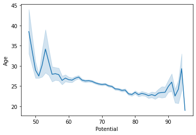

```python
# 16) Scatterplot of relationship between Age and Potential

sns.lineplot(x=df['Potential'],y=df['Age'],)
```

1) The Potential increases gradually as the age decreases

2) The maximum potential point is at the minimum age and the minimum potential point is at maximum age point hence there is an inverse relation

```
                                                    ----------
```

```python
# 17) Features contributing to the wages of the players
# Focusing more on numeric columns
df_num = df.select_dtypes(include=np.number)
df_num
```

|  | ID | Age | Overall | Potential | Value | Wage | International Reputation | Weak Foot | Skill Moves | Joined | ... | Composure | Marking | StandingTackle | SlidingTackle | GKDiving | GKHandling | GKKicking | GKPositioning | GKReflexes | Release Clause |
| --- | --- | --- | --- | --- | --- | --- | --- | --- | --- | --- | --- | --- | --- | --- | --- | --- | --- | --- | --- | --- | --- |
| 0 | 158023 | 31 | 94 | 94 | 110500000.0 | 565000.0 | 5.0 | 4.0 | 4.0 | 2004 | ... | 96.0 | 33.0 | 28.0 | 26.0 | 6.0 | 11.0 | 15.0 | 14.0 | 8.0 | 226500000.0 |
| 1 | 20801 | 33 | 94 | 94 | 77000000.0 | 405000.0 | 5.0 | 4.0 | 5.0 | 2018 | ... | 95.0 | 28.0 | 31.0 | 23.0 | 7.0 | 11.0 | 15.0 | 14.0 | 11.0 | 127100000.0 |
| 2 | 190871 | 26 | 92 | 93 | 118500000.0 | 290000.0 | 5.0 | 5.0 | 5.0 | 2017 | ... | 94.0 | 27.0 | 24.0 | 33.0 | 9.0 | 9.0 | 15.0 | 15.0 | 11.0 | 228100000.0 |
| 3 | 193080 | 27 | 91 | 93 | 72000000.0 | 260000.0 | 4.0 | 3.0 | 1.0 | 2011 | ... | 68.0 | 15.0 | 21.0 | 13.0 | 90.0 | 85.0 | 87.0 | 88.0 | 94.0 | 138600000.0 |
| 4 | 192985 | 27 | 91 | 92 | 102000000.0 | 355000.0 | 4.0 | 5.0 | 4.0 | 2015 | ... | 88.0 | 68.0 | 58.0 | 51.0 | 15.0 | 13.0 | 5.0 | 10.0 | 13.0 | 196400000.0 |
| ... | ... | ... | ... | ... | ... | ... | ... | ... | ... | ... | ... | ... | ... | ... | ... | ... | ... | ... | ... | ... | ... |
| 18202 | 238813 | 19 | 47 | 65 | 60000.0 | 1000.0 | 1.0 | 2.0 | 2.0 | 2017 | ... | 45.0 | 40.0 | 48.0 | 47.0 | 10.0 | 13.0 | 7.0 | 8.0 | 9.0 | 143000.0 |
| 18203 | 243165 | 19 | 47 | 63 | 60000.0 | 1000.0 | 1.0 | 2.0 | 2.0 | 2018 | ... | 42.0 | 22.0 | 15.0 | 19.0 | 10.0 | 9.0 | 9.0 | 5.0 | 12.0 | 113000.0 |
| 18204 | 241638 | 16 | 47 | 67 | 60000.0 | 1000.0 | 1.0 | 3.0 | 2.0 | 2017 | ... | 41.0 | 32.0 | 13.0 | 11.0 | 6.0 | 5.0 | 10.0 | 6.0 | 13.0 | 165000.0 |
| 18205 | 246268 | 17 | 47 | 66 | 60000.0 | 1000.0 | 1.0 | 3.0 | 2.0 | 2018 | ... | 46.0 | 20.0 | 25.0 | 27.0 | 14.0 | 6.0 | 14.0 | 8.0 | 9.0 | 143000.0 |
| 18206 | 246269 | 16 | 46 | 66 | 60000.0 | 1000.0 | 1.0 | 3.0 | 2.0 | 2018 | ... | 43.0 | 40.0 | 43.0 | 50.0 | 10.0 | 15.0 | 9.0 | 12.0 | 9.0 | 165000.0 |

18207 rows × 46 columns

```python
df_num.corr()
```

|  | ID | Age | Overall | Potential | Value | Wage | International Reputation | Weak Foot | Skill Moves | Joined | ... | Composure | Marking | StandingTackle | SlidingTackle | GKDiving | GKHandling | GKKicking | GKPositioning | GKReflexes | Release Clause |
| --- | --- | --- | --- | --- | --- | --- | --- | --- | --- | --- | --- | --- | --- | --- | --- | --- | --- | --- | --- | --- | --- |
| ID | 1.000000 | -0.739208 | -0.417025 | 0.047074 | -0.138194 | -0.204610 | -0.356191 | -0.075784 | -0.056914 | 0.215051 | ... | -0.384473 | -0.110198 | -0.085929 | -0.068409 | -0.105594 | -0.111149 | -0.106652 | -0.118250 | -0.105778 | -0.125303 |
| Age | -0.739208 | 1.000000 | 0.452350 | -0.253312 | 0.075022 | 0.141145 | 0.253765 | 0.059867 | 0.027649 | -0.214809 | ... | 0.391023 | 0.142817 | 0.119745 | 0.103089 | 0.101277 | 0.106419 | 0.104964 | 0.116402 | 0.103313 | 0.065073 |
| Overall | -0.417025 | 0.452350 | 1.000000 | 0.660939 | 0.627085 | 0.571926 | 0.499491 | 0.212015 | 0.414463 | -0.172326 | ... | 0.727655 | 0.286505 | 0.252629 | 0.222811 | -0.025937 | -0.025062 | -0.029372 | -0.017674 | -0.023276 | 0.592035 |
| Potential | 0.047074 | -0.253312 | 0.660939 | 1.000000 | 0.576218 | 0.486413 | 0.372993 | 0.162346 | 0.354290 | -0.043635 | ... | 0.440008 | 0.162801 | 0.143564 | 0.128980 | -0.053446 | -0.054672 | -0.059061 | -0.052589 | -0.053341 | 0.551895 |
| Value | -0.138194 | 0.075022 | 0.627085 | 0.576218 | 1.000000 | 0.858442 | 0.653176 | 0.165221 | 0.315651 | -0.117747 | ... | 0.450352 | 0.133862 | 0.108402 | 0.087735 | -0.028596 | -0.028894 | -0.030923 | -0.027892 | -0.028544 | 0.969670 |
| Wage | -0.204610 | 0.141145 | 0.571926 | 0.486413 | 0.858442 | 1.000000 | 0.668635 | 0.140849 | 0.263205 | -0.146249 | ... | 0.419597 | 0.145594 | 0.126291 | 0.111025 | -0.025595 | -0.025177 | -0.028325 | -0.025489 | -0.025992 | 0.823151 |
| International Reputation | -0.356191 | 0.253765 | 0.499491 | 0.372993 | 0.653176 | 0.668635 | 1.000000 | 0.128317 | 0.208153 | -0.138472 | ... | 0.392787 | 0.115208 | 0.092846 | 0.079176 | 0.004526 | 0.003942 | 0.000651 | 0.006904 | 0.003444 | 0.619546 |
| Weak Foot | -0.075784 | 0.059867 | 0.212015 | 0.162346 | 0.165221 | 0.140849 | 0.128317 | 1.000000 | 0.340721 | -0.014272 | ... | 0.278132 | 0.065673 | 0.042646 | 0.026105 | -0.231905 | -0.233098 | -0.229395 | -0.231298 | -0.232574 | 0.150653 |
| Skill Moves | -0.056914 | 0.027649 | 0.414463 | 0.354290 | 0.315651 | 0.263205 | 0.208153 | 0.340721 | 1.000000 | 0.025112 | ... | 0.586836 | 0.241428 | 0.210517 | 0.178607 | -0.621675 | -0.619755 | -0.616990 | -0.618853 | -0.621925 | 0.291598 |
| Joined | 0.215051 | -0.214809 | -0.172326 | -0.043635 | -0.117747 | -0.146249 | -0.138472 | -0.014272 | 0.025112 | 1.000000 | ... | -0.109474 | -0.096095 | -0.081276 | -0.079945 | -0.084447 | -0.084136 | -0.081484 | -0.088644 | -0.084285 | -0.115256 |
| Weight | -0.191425 | 0.230213 | 0.154634 | -0.006947 | 0.045943 | 0.064776 | 0.088340 | -0.130724 | -0.351209 | -0.029796 | ... | -0.034444 | -0.049356 | -0.046835 | -0.056164 | 0.340034 | 0.339024 | 0.337717 | 0.342178 | 0.341135 | 0.038103 |
| Crossing | -0.131994 | 0.130545 | 0.394972 | 0.246319 | 0.249785 | 0.232834 | 0.191770 | 0.307925 | 0.741035 | -0.024410 | ... | 0.575446 | 0.443101 | 0.428963 | 0.409961 | -0.663053 | -0.660193 | -0.659767 | -0.660160 | -0.662539 | 0.232266 |
| Finishing | -0.082323 | 0.068660 | 0.332515 | 0.243355 | 0.256665 | 0.217439 | 0.178373 | 0.357416 | 0.743439 | 0.042869 | ... | 0.533414 | 0.024218 | -0.033023 | -0.071811 | -0.588752 | -0.587145 | -0.583268 | -0.584852 | -0.586913 | 0.235321 |
| HeadingAccuracy | -0.106815 | 0.147183 | 0.340776 | 0.200988 | 0.184437 | 0.187967 | 0.157483 | 0.183238 | 0.443005 | 0.007342 | ... | 0.507208 | 0.583123 | 0.561063 | 0.533643 | -0.750417 | -0.749888 | -0.746444 | -0.744443 | -0.748895 | 0.170368 |
| ShortPassing | -0.136279 | 0.132894 | 0.502550 | 0.369189 | 0.327623 | 0.296691 | 0.242803 | 0.322133 | 0.730363 | -0.040388 | ... | 0.685137 | 0.559576 | 0.541131 | 0.508644 | -0.729785 | -0.728024 | -0.724381 | -0.723782 | -0.728721 | 0.307361 |
| Volleys | -0.159915 | 0.142472 | 0.391338 | 0.254906 | 0.288243 | 0.257357 | 0.243089 | 0.357340 | 0.745077 | 0.027708 | ... | 0.595281 | 0.120919 | 0.072788 | 0.035457 | -0.590808 | -0.588668 | -0.584954 | -0.586131 | -0.588670 | 0.260973 |
| Dribbling | -0.030340 | 0.010166 | 0.372426 | 0.315019 | 0.272004 | 0.237150 | 0.179041 | 0.352658 | 0.839757 | 0.030073 | ... | 0.597498 | 0.336072 | 0.301251 | 0.273963 | -0.754625 | -0.753181 | -0.749816 | -0.751348 | -0.754341 | 0.251591 |
| Curve | -0.169511 | 0.143276 | 0.419491 | 0.279944 | 0.287235 | 0.259550 | 0.233681 | 0.345468 | 0.771052 | -0.001500 | ... | 0.616532 | 0.289529 | 0.261481 | 0.232869 | -0.606286 | -0.603141 | -0.600266 | -0.603540 | -0.604960 | 0.264707 |
| FKAccuracy | -0.199549 | 0.193467 | 0.396892 | 0.230544 | 0.265773 | 0.236385 | 0.223564 | 0.330472 | 0.701068 | -0.008026 | ... | 0.585120 | 0.297976 | 0.279153 | 0.247903 | -0.556605 | -0.553644 | -0.549911 | -0.552641 | -0.554920 | 0.244333 |
| LongPassing | -0.186764 | 0.181310 | 0.483909 | 0.321437 | 0.302175 | 0.276762 | 0.239525 | 0.277174 | 0.622342 | -0.068590 | ... | 0.645797 | 0.587106 | 0.587430 | 0.562230 | -0.596820 | -0.594999 | -0.591453 | -0.591561 | -0.595887 | 0.284874 |
| BallControl | -0.100184 | 0.084969 | 0.460197 | 0.354396 | 0.308818 | 0.277615 | 0.217946 | 0.356383 | 0.818051 | -0.003142 | ... | 0.674881 | 0.452705 | 0.417566 | 0.384802 | -0.788444 | -0.786797 | -0.783423 | -0.783607 | -0.787939 | 0.286586 |
| Acceleration | 0.133236 | -0.158667 | 0.196869 | 0.234608 | 0.170603 | 0.124985 | 0.044319 | 0.261435 | 0.652356 | 0.070983 | ... | 0.347427 | 0.195369 | 0.163000 | 0.157565 | -0.593008 | -0.594866 | -0.592127 | -0.592143 | -0.593201 | 0.160261 |
| SprintSpeed | 0.132437 | -0.151682 | 0.210647 | 0.236771 | 0.172677 | 0.130315 | 0.044070 | 0.248822 | 0.624098 | 0.072229 | ... | 0.351607 | 0.212575 | 0.178214 | 0.171980 | -0.597677 | -0.599694 | -0.597320 | -0.596498 | -0.597837 | 0.162528 |
| Agility | -0.019897 | -0.019395 | 0.264952 | 0.222310 | 0.194259 | 0.156287 | 0.100869 | 0.302062 | 0.681765 | 0.012187 | ... | 0.432511 | 0.167122 | 0.129204 | 0.116686 | -0.527756 | -0.528482 | -0.527164 | -0.526983 | -0.528899 | 0.179479 |
| Reactions | -0.408617 | 0.453124 | 0.850045 | 0.513425 | 0.540552 | 0.495560 | 0.445614 | 0.201341 | 0.377044 | -0.166635 | ... | 0.685558 | 0.283607 | 0.255399 | 0.228355 | -0.062967 | -0.061940 | -0.065927 | -0.055031 | -0.059961 | 0.511637 |
| Balance | 0.048463 | -0.089877 | 0.103160 | 0.138025 | 0.113726 | 0.088873 | 0.050076 | 0.254022 | 0.578459 | 0.009920 | ... | 0.310763 | 0.178695 | 0.154045 | 0.152470 | -0.504727 | -0.506102 | -0.503970 | -0.503652 | -0.505974 | 0.107576 |
| ShotPower | -0.166133 | 0.156947 | 0.441118 | 0.288318 | 0.281360 | 0.258351 | 0.227772 | 0.332855 | 0.718237 | 0.018422 | ... | 0.634495 | 0.296944 | 0.256403 | 0.220237 | -0.654117 | -0.654099 | -0.649403 | -0.651409 | -0.653475 | 0.257405 |
| Jumping | -0.169369 | 0.177167 | 0.264435 | 0.109151 | 0.124515 | 0.129691 | 0.120931 | 0.069752 | 0.107553 | -0.051240 | ... | 0.252353 | 0.279196 | 0.260645 | 0.260261 | -0.192700 | -0.193692 | -0.195282 | -0.189079 | -0.192050 | 0.115995 |
| Stamina | -0.053895 | 0.097793 | 0.365656 | 0.202563 | 0.210721 | 0.177562 | 0.094780 | 0.232094 | 0.570226 | -0.016172 | ... | 0.523112 | 0.587782 | 0.570055 | 0.544702 | -0.701467 | -0.698556 | -0.696729 | -0.696073 | -0.699670 | 0.197468 |
| Strength | -0.259756 | 0.332798 | 0.349326 | 0.075769 | 0.128924 | 0.139360 | 0.131280 | -0.008470 | -0.041475 | -0.066346 | ... | 0.280522 | 0.333334 | 0.332159 | 0.304849 | -0.111012 | -0.109660 | -0.110253 | -0.103878 | -0.107497 | 0.116748 |
| LongShots | -0.161549 | 0.155096 | 0.420795 | 0.266740 | 0.279730 | 0.249084 | 0.213960 | 0.355967 | 0.752980 | 0.007085 | ... | 0.616102 | 0.215510 | 0.172331 | 0.133603 | -0.612381 | -0.610739 | -0.605952 | -0.607200 | -0.610087 | 0.255539 |
| Aggression | -0.228329 | 0.265190 | 0.395470 | 0.171174 | 0.184639 | 0.194581 | 0.173327 | 0.131524 | 0.347795 | -0.061431 | ... | 0.515776 | 0.723961 | 0.744216 | 0.721384 | -0.575843 | -0.576114 | -0.573607 | -0.571201 | -0.575142 | 0.173931 |
| Interceptions | -0.160602 | 0.197845 | 0.321326 | 0.154908 | 0.140666 | 0.157415 | 0.129586 | 0.053097 | 0.209604 | -0.105769 | ... | 0.397450 | 0.888349 | 0.941471 | 0.928282 | -0.485585 | -0.486324 | -0.485394 | -0.481279 | -0.486036 | 0.137279 |
| Positioning | -0.088330 | 0.082443 | 0.356493 | 0.245616 | 0.259391 | 0.226775 | 0.183003 | 0.346896 | 0.781248 | 0.020792 | ... | 0.580498 | 0.202597 | 0.158060 | 0.124228 | -0.679480 | -0.677699 | -0.674393 | -0.675569 | -0.678582 | 0.237809 |
| Vision | -0.215170 | 0.187422 | 0.498894 | 0.348141 | 0.357639 | 0.315395 | 0.284600 | 0.337897 | 0.674057 | -0.053196 | ... | 0.636280 | 0.176760 | 0.146460 | 0.113228 | -0.381899 | -0.377807 | -0.374737 | -0.375775 | -0.381158 | 0.333553 |
| Penalties | -0.140657 | 0.139535 | 0.341429 | 0.224281 | 0.239033 | 0.222440 | 0.218620 | 0.330252 | 0.690434 | 0.036620 | ... | 0.551801 | 0.152296 | 0.101920 | 0.066693 | -0.620069 | -0.618968 | -0.614006 | -0.617074 | -0.619099 | 0.218507 |
| Composure | -0.384473 | 0.391023 | 0.727655 | 0.440008 | 0.450352 | 0.419597 | 0.392787 | 0.278132 | 0.586836 | -0.109474 | ... | 1.000000 | 0.384081 | 0.351726 | 0.317492 | -0.378750 | -0.375720 | -0.374897 | -0.370234 | -0.377626 | 0.422572 |
| Marking | -0.110198 | 0.142817 | 0.286505 | 0.162801 | 0.133862 | 0.145594 | 0.115208 | 0.065673 | 0.241428 | -0.096095 | ... | 0.384081 | 1.000000 | 0.906541 | 0.895908 | -0.550978 | -0.552263 | -0.549498 | -0.546670 | -0.551290 | 0.129550 |
| StandingTackle | -0.085929 | 0.119745 | 0.252629 | 0.143564 | 0.108402 | 0.126291 | 0.092846 | 0.042646 | 0.210517 | -0.081276 | ... | 0.351726 | 0.906541 | 1.000000 | 0.974659 | -0.530989 | -0.532160 | -0.531092 | -0.527792 | -0.531474 | 0.108357 |
| SlidingTackle | -0.068409 | 0.103089 | 0.222811 | 0.128980 | 0.087735 | 0.111025 | 0.079176 | 0.026105 | 0.178607 | -0.079945 | ... | 0.317492 | 0.895908 | 0.974659 | 1.000000 | -0.509337 | -0.510591 | -0.509378 | -0.505792 | -0.509425 | 0.089532 |
| GKDiving | -0.105594 | 0.101277 | -0.025937 | -0.053446 | -0.028596 | -0.025595 | 0.004526 | -0.231905 | -0.621675 | -0.084447 | ... | -0.378750 | -0.550978 | -0.530989 | -0.509337 | 1.000000 | 0.970280 | 0.965685 | 0.969864 | 0.973320 | -0.024011 |
| GKHandling | -0.111149 | 0.106419 | -0.025062 | -0.054672 | -0.028894 | -0.025177 | 0.003942 | -0.233098 | -0.619755 | -0.084136 | ... | -0.375720 | -0.552263 | -0.532160 | -0.510591 | 0.970280 | 1.000000 | 0.965239 | 0.969408 | 0.970264 | -0.023953 |
| GKKicking | -0.106652 | 0.104964 | -0.029372 | -0.059061 | -0.030923 | -0.028325 | 0.000651 | -0.229395 | -0.616990 | -0.081484 | ... | -0.374897 | -0.549498 | -0.531092 | -0.509378 | 0.965685 | 0.965239 | 1.000000 | 0.964336 | 0.966337 | -0.025900 |
| GKPositioning | -0.118250 | 0.116402 | -0.017674 | -0.052589 | -0.027892 | -0.025489 | 0.006904 | -0.231298 | -0.618853 | -0.088644 | ... | -0.370234 | -0.546670 | -0.527792 | -0.505792 | 0.969864 | 0.969408 | 0.964336 | 1.000000 | 0.970130 | -0.022365 |
| GKReflexes | -0.105778 | 0.103313 | -0.023276 | -0.053341 | -0.028544 | -0.025992 | 0.003444 | -0.232574 | -0.621925 | -0.084285 | ... | -0.377626 | -0.551290 | -0.531474 | -0.509425 | 0.973320 | 0.970264 | 0.966337 | 0.970130 | 1.000000 | -0.023794 |
| Release Clause | -0.125303 | 0.065073 | 0.592035 | 0.551895 | 0.969670 | 0.823151 | 0.619546 | 0.150653 | 0.291598 | -0.115256 | ... | 0.422572 | 0.129550 | 0.108357 | 0.089532 | -0.024011 | -0.023953 | -0.025900 | -0.022365 | -0.023794 | 1.000000 |

46 rows × 46 columns

Using Correlation understanding the impact of other factors on Wage of a player Inferences:

--- Overall, Potential, Value, International Reputation and Release Clause impact the wage of a player. Remaining factors have very less impact on the wage of a player. These above mentioned factors seem to have positive correlation with the Wage factor.

```
                                                        ----------
```

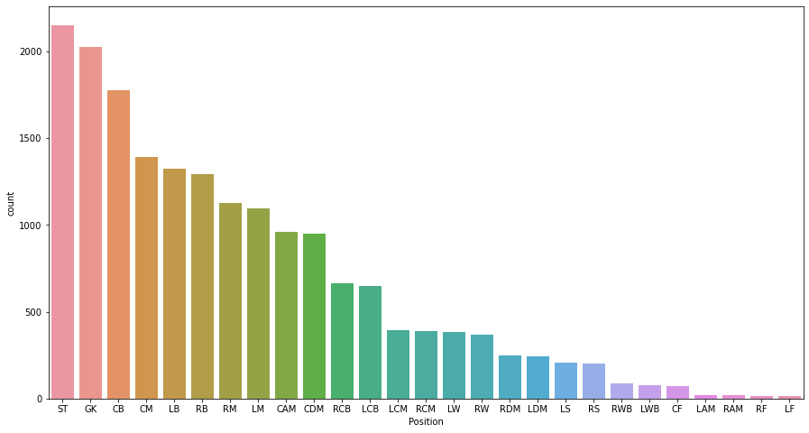

```python
# 18) Position with maximum and minimum number of players
fig, ax = plt.subplots(figsize=(15, 8))
sns.countplot(x=df['Position'],order=df['Position'].value_counts(ascending=False).index)
```

```
                                                        ----------
```

```python
# 19) Players from Juventus earning more than 200000
df.loc[(df['Club']=='Juventus') & (df['Wage']>200000)]
```

|  | ID | Name | Age | Nationality | Overall | Potential | Club | Value | Wage | Preferred Foot | ... | Composure | Marking | StandingTackle | SlidingTackle | GKDiving | GKHandling | GKKicking | GKPositioning | GKReflexes | Release Clause |
| --- | --- | --- | --- | --- | --- | --- | --- | --- | --- | --- | --- | --- | --- | --- | --- | --- | --- | --- | --- | --- | --- |
| 1 | 20801 | Cristiano Ronaldo | 33 | Portugal | 94 | 94 | Juventus | 77000000.0 | 405000.0 | Right | ... | 95.0 | 28.0 | 31.0 | 23.0 | 7.0 | 11.0 | 15.0 | 14.0 | 11.0 | 127100000.0 |
| 15 | 211110 | P. Dybala | 24 | Argentina | 89 | 94 | Juventus | 89000000.0 | 205000.0 | Left | ... | 84.0 | 23.0 | 20.0 | 20.0 | 5.0 | 4.0 | 4.0 | 5.0 | 8.0 | 153500000.0 |
| 24 | 138956 | G. Chiellini | 33 | Italy | 89 | 89 | Juventus | 27000000.0 | 215000.0 | Left | ... | 84.0 | 93.0 | 93.0 | 90.0 | 3.0 | 3.0 | 2.0 | 4.0 | 3.0 | 44600000.0 |

3 rows × 55 columns

There are 3 players who earn more than 200k in Juventus Football Club

```
                                                    ----------
```

```python
# 20) Top 5 players by Overall per position
top_5_per_position = df.groupby('Position').apply(lambda x : x.sort_values(by = 'Overall', ascending = False).head(5).reset_index(drop = True))
top_5_per_position
```

| Position |  | ID | Name | Age | Nationality | Overall | Potential | Club | Value | Wage | Preferred Foot | ... | Composure | Marking | StandingTackle | SlidingTackle | GKDiving | GKHandling | GKKicking | GKPositioning | GKReflexes | Release Clause |
| --- | --- | --- | --- | --- | --- | --- | --- | --- | --- | --- | --- | --- | --- | --- | --- | --- | --- | --- | --- | --- | --- | --- |
| CAM | 0 | 194765 | A. Griezmann | 27 | France | 89 | 90 | Atlético Madrid | 78000000.0 | 145000.0 | Left | ... | 87.0 | 59.0 | 47.0 | 48.0 | 14.0 | 8.0 | 14.0 | 13.0 | 14.0 | 165800000.0 |
|  | 1 | 190460 | C. Eriksen | 26 | Denmark | 88 | 91 | Tottenham Hotspur | 73500000.0 | 205000.0 | Right | ... | 88.0 | 59.0 | 57.0 | 22.0 | 9.0 | 14.0 | 7.0 | 7.0 | 6.0 | 141500000.0 |
|  | 2 | 201942 | Roberto Firmino | 26 | Brazil | 86 | 87 | Liverpool | 53000000.0 | 195000.0 | Right | ... | 87.0 | 60.0 | 64.0 | 42.0 | 8.0 | 11.0 | 9.0 | 6.0 | 10.0 | 104700000.0 |
|  | 3 | 189596 | T. Müller | 28 | Germany | 86 | 86 | FC Bayern München | 45000000.0 | 135000.0 | Right | ... | 83.0 | 44.0 | 41.0 | 44.0 | 6.0 | 7.0 | 11.0 | 14.0 | 14.0 | 74300000.0 |
|  | 4 | 176635 | M. Özil | 29 | Germany | 86 | 86 | Arsenal | 43500000.0 | 190000.0 | Left | ... | 82.0 | 24.0 | 16.0 | 19.0 | 6.0 | 14.0 | 10.0 | 6.0 | 14.0 | 82700000.0 |
| ... | ... | ... | ... | ... | ... | ... | ... | ... | ... | ... | ... | ... | ... | ... | ... | ... | ... | ... | ... | ... | ... | ... |
| ST | 0 | 20801 | Cristiano Ronaldo | 33 | Portugal | 94 | 94 | Juventus | 77000000.0 | 405000.0 | Right | ... | 95.0 | 28.0 | 31.0 | 23.0 | 7.0 | 11.0 | 15.0 | 14.0 | 11.0 | 127100000.0 |
|  | 1 | 188545 | R. Lewandowski | 29 | Poland | 90 | 90 | FC Bayern München | 77000000.0 | 205000.0 | Right | ... | 86.0 | 34.0 | 42.0 | 19.0 | 15.0 | 6.0 | 12.0 | 8.0 | 10.0 | 127100000.0 |
|  | 2 | 202126 | H. Kane | 24 | England | 89 | 91 | Tottenham Hotspur | 83500000.0 | 205000.0 | Right | ... | 89.0 | 56.0 | 36.0 | 38.0 | 8.0 | 10.0 | 11.0 | 14.0 | 11.0 | 160700000.0 |
|  | 3 | 153079 | S. Agüero | 30 | Argentina | 89 | 89 | Manchester City | 64500000.0 | 300000.0 | Right | ... | 90.0 | 30.0 | 20.0 | 12.0 | 13.0 | 15.0 | 6.0 | 11.0 | 14.0 | 119300000.0 |
|  | 4 | 173731 | G. Bale | 28 | Wales | 88 | 88 | Real Madrid | 60000000.0 | 355000.0 | Left | ... | 86.0 | 54.0 | 55.0 | 52.0 | 15.0 | 15.0 | 11.0 | 5.0 | 6.0 | 123000000.0 |

135 rows × 55 columns

```
                                                    ----------
```

```python
# 21) Average wage of top 5 players in each position
Avg_Wage_Top5_byposition = top_5_per_position['Wage'].groupby('Position').mean()
Avg_Wage_Top5_byposition
```

```
Position
CAM    174000.0
CB     139600.0
CDM    217000.0
CF      47400.0
CM     130600.0
GK     192800.0
LAM     81600.0
LB     177200.0
LCB    162000.0
LCM    184400.0
LDM    126600.0
LF     121200.0
LM     164600.0
LS     130200.0
LW     261000.0
LWB     34200.0
RAM     45400.0
RB     155400.0
RCB    231000.0
RCM    240800.0
RDM    105000.0
RF     148000.0
RM     131400.0
RS     132200.0
RW     202000.0
RWB     44200.0
ST     294000.0
Name: Wage, dtype: float64
```

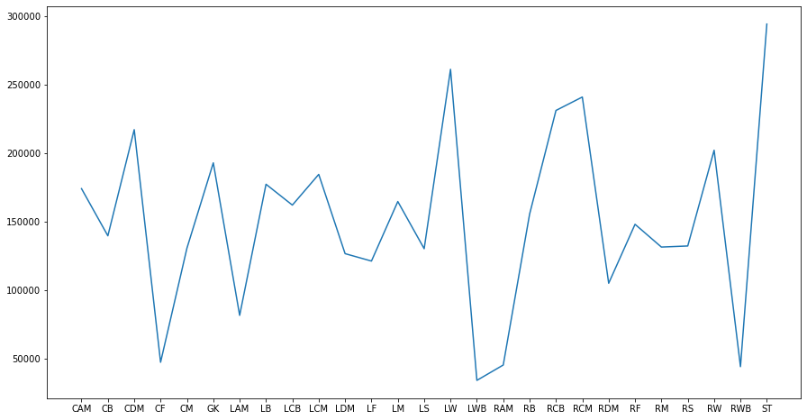

```python
# Plotting the mean wage of top 5 players in each position
fig, ax = plt.subplots(figsize=(15, 8))
plt.plot(Avg_Wage_Top5_byposition)
```

```
                                                        ----------
```

```
                                                -----THE END----
```